# Project Python Foundations: FoodHub Data Analysis

### **Question 7**: Which are the top 5 restaurants in terms of the number of orders received? [1 mark]

```python
df['restaurant_name'].value_counts().head(5)
```

| restaurant_name | count |
| --- | --- |
| Shake Shack | 219 |
| The Meatball Shop | 132 |
| Blue Ribbon Sushi | 119 |
| Blue Ribbon Fried Chicken | 96 |
| Parm | 68 |

**dtype:** int64

#### Observations:

Top 5 restaurants in terms of the number of orders received are

- Shake Shack : 219 orders
- The Meatball Shop : 132 orders
- Blue Ribbon Sushi : 119 orders
- Blue Ribbon Fried Chicken: 96 orders
- Parm: 68 orders

### **Question 8**: Which is the most popular cuisine on weekends? [1 mark]

```python
weekend_data=df[df['day_of_the_week'] == 'Weekend']
weekend_data['cuisine_type'].value_counts().head(1)
```

| cuisine_type | count |
| --- | --- |
| American | 415 |

**dtype:** int64

#### Observations:

Most popular cuisine on weekends is

- American : 415 Orders

### **Question 9**: What percentage of the orders cost more than 20 dollars? [2 marks]

```python
total_order = len(df)
order_cost_gt20 =len(df[df['cost_of_the_order']>20])
percentage_cost_gt20 = (order_cost_gt20 / total_order) * 100
print('Percentage of the orders cost more than 20 dollars', format(percentage_cost_gt20,".2f"))
```

```
Percentage of the orders cost more than 20 dollars 29.24
```

#### Observations:

- Approx 29.24% of the orders cost more than $20
- Approx 70.76% of orders are less than $20, indicates that the platform caters budget consious customers

### **Question 10**: What is the mean order delivery time? [1 mark]

```python
mean_delivery_time=df['delivery_time'].sum()/len(df)
print('Mean order delivery time is ',format(mean_delivery_time,".2f"), 'minutes')
```

```
Mean order delivery time is  24.16 minutes
```

#### Observations:

- Mean order delivery time is 24.16 minutes

### **Question 11:** The company has decided to give 20% discount vouchers to the top 3 most frequent customers. Find the IDs of these customers and the number of orders they placed. [1 mark]

```python
df['customer_id'].value_counts().head(3)
#print('IDs of Customer and number of orders are :- ',three_frequent_customer)
```

| customer_id | count |
| --- | --- |
| 52832 | 13 |
| 47440 | 10 |
| 83287 | 9 |

**dtype:** int64

#### Observations:

IDs of top 3 customers and their number of orders -

- customer_id **52832** has placed **13** Orders
- customer_id **47440** has placed **10** Orders
- customer_id **83287** has placed **9** Orders

### **Question 12**: Perform a multivariate analysis to explore relationships between the important variables in the dataset. (It is a good idea to explore relations between numerical variables as well as relations between numerical and categorical variables) [10 marks]

Relationship between Numerical Variables (Cost of Order, Food Preparation Time and Delivery Time)

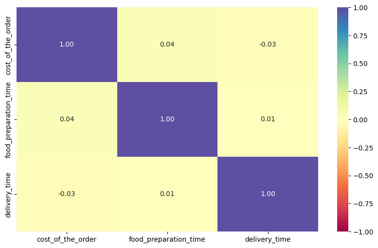

```python
#  relationship between numerical variables[c]
plt.figure(figsize=(10,6))
corr=df[['cost_of_the_order','food_preparation_time','delivery_time']].corr()
sns.heatmap(corr,annot=True, vmin=-1, vmax=1, fmt=".2f", cmap="Spectral")
plt.show()
```

Observations :

- cost_of_the_order has negligible correlations with preparation time or delivery times.
- Numerical variables(cost_of_the_order,preparation time and delivery times) have weak correlation

Relationship between Numeric and Categorical Variables

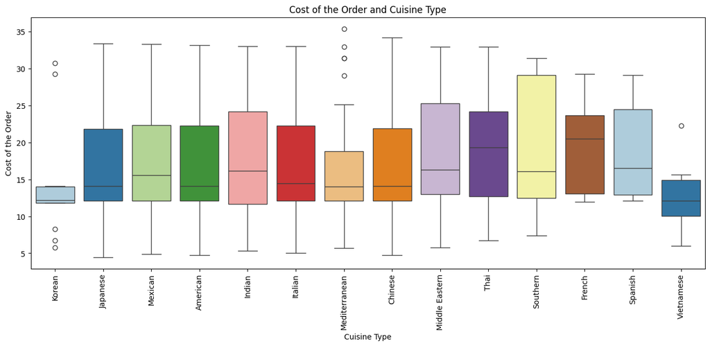

```python
#  cost of the order and Cuisine Type relationship

plt.figure(figsize=(16, 6))
sns.boxplot(data=df, x='cuisine_type', y='cost_of_the_order',palette ="Paired",hue='cuisine_type')
plt.title('Cost of the Order and Cuisine Type')
plt.xlabel('Cuisine Type')
plt.ylabel('Cost of the Order')
plt.xticks(rotation=90)
plt.show()
```

Observations -

- Significant variation in the cost of orders across cuisine types.
- French cuisine has the highest mean ~20 costs, reflecting its premium pricing.
- Amercan and Chinese Cuisines has similar mean costs (~$16), suggesting standardized pricing strategies.
- Italian cuisine shows slightly higher mean and median costs compared to American and Chinese cuisines.

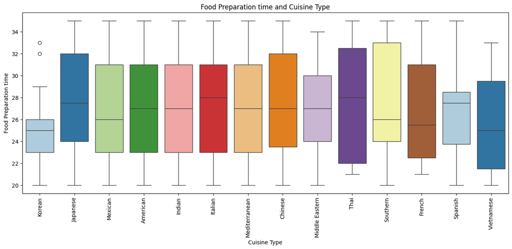

```python
#  Food Preparation time and Cuisine relationship
plt.figure(figsize=(16, 6))
sns.boxplot(data=df, x='cuisine_type',y='food_preparation_time',palette ="Paired",hue='cuisine_type')
plt.title('Food Preparation time and Cuisine Type')
plt.xlabel('Cuisine Type')
plt.ylabel('Food Preparation time')
plt.xticks(rotation=90)
plt.show()
```

Observations :

- Most Cuisines has average Food preparation time around 27 minutes which indicated food preparation time across cuisines is highly consistent.
- For all cuisines, preparation times range from 20 to 35 minutes, indicating well-regulated processes.
- Chinese and Italian hows slightly higher average preparation times (27.51 and 27.48 minutes than French cuisine.

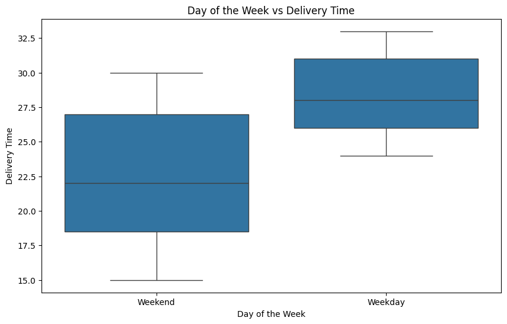

```python
# Day of the week and Delivery time
plt.figure(figsize=(10,6))
sns.boxplot(data=df,x='day_of_the_week',y='delivery_time')
plt.title('Day of the Week vs Delivery Time')
plt.xlabel('Day of the Week')
plt.ylabel('Delivery Time')
plt.show()
```

Observations -

Rating and Delivery time relationship

[figure not shown]

```python
temp_data=df.copy()
temp_data['rating']=pd.to_numeric(temp_data['rating'],errors='coerce')
plt.figure(figsize=(10, 6))
plt.scatter(temp_data['rating'],temp_data['delivery_time'])
plt.title('Relationship Between Delivery Time and Rating')
plt.xlabel('Delivery Time')
plt.ylabel('Rating')
```

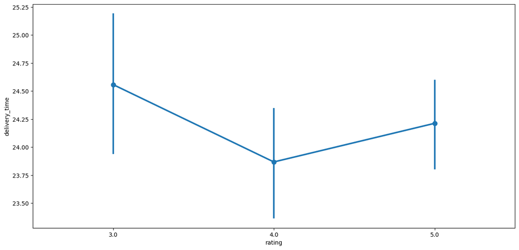

```python
plt.figure(figsize=(15, 7))
sns.pointplot(x = 'rating', y = 'delivery_time', data = temp_data)
plt.show()
```

Observations -

- The mean delivery times for Ratings(3, 4, and 5) are ~(24.5, 24, and 24.25 minutes, respectively). This suggests that delivery time alone may not be the sole factor influencing ratings.
- Ratings do not drastically improve with shorter delivery times.Other factors such as food quality and customer service play significant role in customer satisfaction.

Rating and Food Preparation time relationship

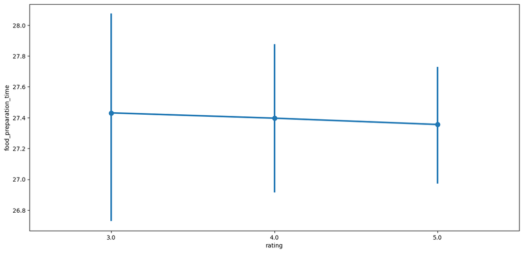

```python
plt.figure(figsize=(15, 7))
sns.pointplot(x = 'rating', y = 'food_preparation_time', data = temp_data)
plt.show()
```

Observations :

- The average food preparation time is almost identical(~27.4) min for all ratings, indicating that preparation time alone does not have a strong influence on customer ratings.
- Since food preparation time is consistent across ratings, factors such as food quality, delivery time, or overall service might play role in customer satisfaction

Rating and cost of the Order Relationship

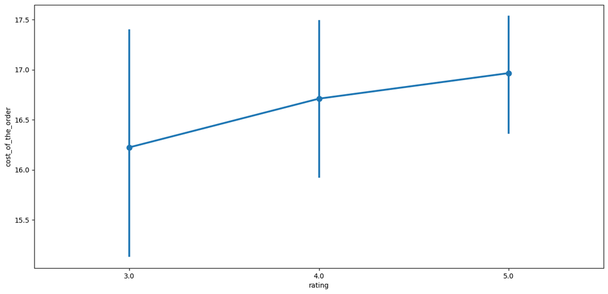

```python
plt.figure(figsize=(15, 7))
sns.pointplot(x = 'rating', y = 'cost_of_the_order', data = temp_data)
plt.show()
```

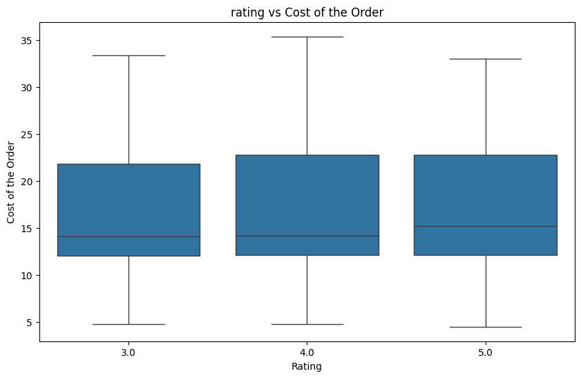

```python
plt.figure(figsize=(10,6))
sns.boxplot(data=temp_data,x='rating',y='cost_of_the_order')
plt.title('rating vs Cost of the Order')
plt.xlabel('Rating')
plt.ylabel('Cost of the Order')
plt.show()
```

Observations :

- Orders with higher ratings (5) have slightly higher mean and median costs compared to lower ratings.
- The interquartile range (IQR) and overall cost ranges are similar for all ratings, suggesting that cost is not a major differentiator among customer ratings
- The weak difference in mean costs across ratings implies that other factors, such as delivery time, preparation time, or food quality, likely have a stronger impact on customer ratings than the cost.

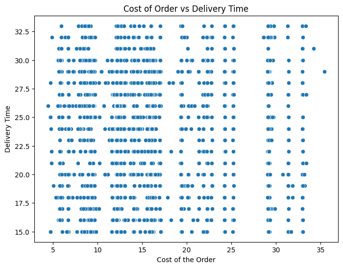

```python
# Numerical Variables Relationship
#cost_of_the_order and delivery_time.
#cost_of_the_order and food_preparation_time.
#delivery_time and food_preparation_time.

# Scatter Plot: Cost of Order vs Delivery Time
plt.figure(figsize=(8, 6))
sns.scatterplot(data=df, x='cost_of_the_order', y='delivery_time')
plt.title('Cost of Order vs Delivery Time')
plt.xlabel('Cost of the Order')
plt.ylabel('Delivery Time')
plt.show()
```

Observations :

- There is no clear relationship between the cost of the order and delivery time. Orders with a wide range of costs tend to be delivered within a similar time frame (15–30 minutes)
- High-cost and low-cost orders are distributed across varying delivery times.
- A few high-cost orders are associated with both shorter and longer delivery times, suggesting that delivery efficiency may not be consistently tied to the order value

### **Question 13:** The company wants to provide a promotional offer in the advertisement of the restaurants. The condition to get the offer is that the restaurants must have a rating count of more than 50 and the average rating should be greater than 4. Find the restaurants fulfilling the criteria to get the promotional offer. [3 marks]

```python
temp_data=df.copy()
# Converting rating to numeric by converting the "Not given" value to NaN
temp_data['rating']=pd.to_numeric(temp_data['rating'],errors='coerce')
# Group by restaurant anc calculate the average rating and count
rest_rating=temp_data.groupby('restaurant_name')['rating'].agg(['mean','count']).reset_index()
#condition check for the average rating and count
rest_rating[(rest_rating['count'] > 50) & (rest_rating['mean'] > 4)]
```

|  | restaurant_name | mean | count |
| --- | --- | --- | --- |
| 20 | Blue Ribbon Fried Chicken | 4.328125 | 64 |
| 21 | Blue Ribbon Sushi | 4.219178 | 73 |
| 136 | Shake Shack | 4.278195 | 133 |
| 153 | The Meatball Shop | 4.511905 | 84 |

#### Observations:

- Only four restaurants(**Blue Ribbon Fried Chicken,Blue Ribbon Sushi,Shake Shack,The Meatball Shop**) meet the criteria of having an average rating > 4 and a rating count > 50.
  1. Blue Ribbon Fried Chicken: 64 ratings, average rating 4.33
  2. Blue Ribbon Sushi: 73 ratings, average rating 4.22
  3. Shake Shack: 133 ratings, average rating 4.28
  4. The Meatball Shop: 84 ratings, average rating 4.51
- Shake Shack has the highest rating of 133 , indicates popularity and customer engagement
- The Meatball shop has the highest average rating of 4.51 , indicating exceptional customer satisfaction
- Blue Ribbon Fried Chicken and Blue Ribbon Sushi has balance between the average rating and rating count.

### **Question 14:** The company charges the restaurant 25% on the orders having cost greater than 20 dollars and 15% on the orders having cost greater than 5 dollars. Find the net revenue generated by the company across all orders. [3 marks]

```python
def revenue_calculation(ordercost):
    if ordercost > 20:
        return ordercost * 0.25
    elif ordercost > 5:
        return ordercost * 0.15
    else:
        return 0

df['revenue'] = df['cost_of_the_order'].apply(revenue_calculation)

total_revenue = df['revenue'].sum()
print('Net Revenue Generated is :-','$',format(total_revenue,".2f"))
```

```
Net Revenue Generated is :- $ 6166.30
```

#### Observations:

- Net Revenue Generated is :- $6166.30

### **Question 15:** The company wants to analyze the total time required to deliver the food. What percentage of orders take more than 60 minutes to get delivered from the time the order is placed? (The food has to be prepared and then delivered.) [2 marks]

```python
# Write the code here
df['total_time']=df['food_preparation_time'] + df['delivery_time']
len(df)
len(df[(df['food_preparation_time'] + df['delivery_time']) > 60])
percentage_deliver_time_gt60 = (len(df[(df['food_preparation_time'] + df['delivery_time']) > 60]) / len(df))*100
print('Percentage of orders taking more than 60 minutes to be delivered from the time the order is placed is',format(percentage_deliver_time_gt60,".2f"),'%')
```

[output not shown]

#### Observations:

- Percentage of orders taking more than 60 minutes to be delivered from the time the order is placed is 10.54%

### **Question 16:** The company wants to analyze the delivery time of the orders on weekdays and weekends. How does the mean delivery time vary during weekdays and weekends? [2 marks]

```python
# Write the code here
mean_delivery_time = df.groupby('day_of_the_week')['delivery_time'].mean()
mean_delivery_time
```

| day_of_the_week | delivery_time |
| --- | --- |
| Weekday | 28.340037 |
| Weekend | 22.470022 |

**dtype:** float64

#### Observations:

Mean Delivery time during Weekends and Weekdays are

- Weekday delivery time is 28.34 minutes
- Weekend delivery time is 22.47 minutes

### **Question 17:** What are your conclusions from the analysis? What recommendations would you like to share to help improve the business? (You can use cuisine type and feedback ratings to drive your business recommendations.) [6 marks]

### Conclusions:

**Ratings Feedback** -

- Approx 39% of the orders have feedback as "Not given" leading to a gap in understanding customer satisfaction.
- A majority are positive (4 or 5 stars), indicating general satisfaction with the service.
- 3 stars Rating are minimal but need to be analyzed in the context of delays, high costs, or food quality.

**Cuisine Types**

**Food Preparation and Delivery Time**

- Delivery time does not strong correlation with ratings, excessively high preparation times or delivery delays can still impact customer experience.

**Cuisine vs. Ratings**

- Underrepresented cuisines may have fewer ratings, which could limit insights into their performance
- Popular cuisines like American have a higher chances of receiving positive ratings due to universally accepted by all population segments.

### Recommendations:

**Feedback Collection Enhancement**

- Incentivize customers with discounts or loyalty points for leaving reviews, especially for underrepresented cuisines.
- Simplify the feedback process in the app.
- Investigate and address recurring issues leading to poor feedback .
- Provide targeted support for dissatisfied customers such as refunds.

**Cuisine Strategies**

- Promote Underpresented Cuisines :- Feature those cuisines in marketing campaign to increase customer interest
- Add small portion of these cuisines as freebie with the high selling cuisines for the customer to have the taste and increase customer awareness.
- Offer bundle deals or promotions for popular dishes to increase order frequency

**Personlized Marketing**

- Use of past ratings and order history to create personalized offers.
- Offer weekday discounts to encourage orders during off-peak times.

**Improve Food Preparation and Delivery Times**

- Identify restaurants with consistently long preparation times and work with them to improve efficiency.
- Create a reward system for restaurants with quick preparation times and high customer ratings.

**Data-Driven cross Restaurant Support**

- Conduct training sessions for underperforming restaurants to align them with customer expectations.
- Sharing of performance metrics (e.g., ratings, preparation times) with partner restaurants to help them improve.